# Titanic2

### **Exploring the Titanic Dataset**

```python
%matplotlib inline
import pandas as pd
import matplotlib.pyplot as plt
import seaborn as sns
import numpy as np
import pandas_profiling
```

```python
from sklearn.model_selection import train_test_split, cross_val_score
from sklearn.ensemble import RandomForestClassifier, GradientBoostingClassifier
from sklearn.linear_model import LogisticRegression, SGDClassifier
from sklearn.svm import SVC
from sklearn.tree import DecisionTreeClassifier
from sklearn.naive_bayes import GaussianNB
from sklearn.neighbors import KNeighborsClassifier
```

```python
import warnings
warnings.filterwarnings('ignore')
```

#### **We Import our Data**

```python
titanic = sns.load_dataset('titanic')
titanic.head()
```

|  | survived | pclass | sex | age | sibsp | parch | fare | embarked | class | who | adult_male | deck | embark_town | alive | alone |
| --- | --- | --- | --- | --- | --- | --- | --- | --- | --- | --- | --- | --- | --- | --- | --- |
| 0 | 0 | 3 | male | 22.0 | 1 | 0 | 7.2500 | S | Third | man | True | NaN | Southampton | no | False |
| 1 | 1 | 1 | female | 38.0 | 1 | 0 | 71.2833 | C | First | woman | False | C | Cherbourg | yes | False |
| 2 | 1 | 3 | female | 26.0 | 0 | 0 | 7.9250 | S | Third | woman | False | NaN | Southampton | yes | True |
| 3 | 1 | 1 | female | 35.0 | 1 | 0 | 53.1000 | S | First | woman | False | C | Southampton | yes | False |
| 4 | 0 | 3 | male | 35.0 | 0 | 0 | 8.0500 | S | Third | man | True | NaN | Southampton | no | True |

```python
titanic.shape
```

```
(891, 15)
```

```python
titanic.describe().T
```

|  | count | mean | std | min | 25% | 50% | 75% | max |
| --- | --- | --- | --- | --- | --- | --- | --- | --- |
| survived | 891.0 | 0.383838 | 0.486592 | 0.00 | 0.0000 | 0.0000 | 1.0 | 1.0000 |
| pclass | 891.0 | 2.308642 | 0.836071 | 1.00 | 2.0000 | 3.0000 | 3.0 | 3.0000 |
| age | 714.0 | 29.699118 | 14.526497 | 0.42 | 20.1250 | 28.0000 | 38.0 | 80.0000 |
| sibsp | 891.0 | 0.523008 | 1.102743 | 0.00 | 0.0000 | 0.0000 | 1.0 | 8.0000 |
| parch | 891.0 | 0.381594 | 0.806057 | 0.00 | 0.0000 | 0.0000 | 0.0 | 6.0000 |
| fare | 891.0 | 32.204208 | 49.693429 | 0.00 | 7.9104 | 14.4542 | 31.0 | 512.3292 |

```python
titanic.dtypes
```

```
survived          int64
pclass            int64
sex              object
age             float64
sibsp             int64
parch             int64
fare            float64
embarked         object
class          category
who              object
adult_male         bool
deck           category
embark_town      object
alive            object
alone              bool
dtype: object
```

```python
# We determine the missing values and percentage missing values per feature

total = titanic.isnull().sum().sort_values(ascending=False)
percent = ((titanic.isnull().sum().sort_values(ascending=False))/len(titanic))*100
percent = round(percent, 2)
missing = pd.concat([total, percent], axis=1, keys=['missing val', 'percent'])
missing[missing['missing val']>0]
```

|  | missing val | percent |
| --- | --- | --- |
| deck | 688 | 77.22 |
| age | 177 | 19.87 |
| embark_town | 2 | 0.22 |
| embarked | 2 | 0.22 |

#### **Analysis of the Feature Age**

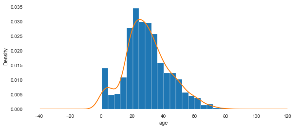

```python
ax = titanic.age.hist(bins=20, figsize=(10, 4), density=True)
titanic.age.plot(kind='density')
ax.set_xlabel('age')
```

##### Let us see the survival distribution of men, women and children.

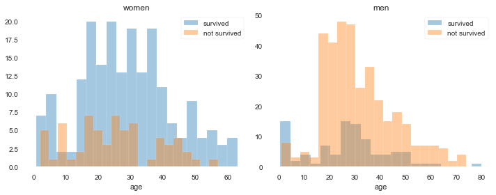

```python
survived = 'survived'
not_survived = 'not survived'

fig, axes = plt.subplots(1, 2, figsize=(10, 4))

women = titanic[titanic['sex']=='female']
men = titanic[titanic['sex']=='male']

ax = sns.distplot(women[women[survived]==1]['age'].dropna(), label=survived, bins=20, ax=axes[0], kde=False)
ax = sns.distplot(women[women[survived]==0]['age'].dropna(), label=not_survived, bins=20, ax=axes[0], kde=False)
ax.legend(loc='best')
ax.set_title('women')

ax = sns.distplot(men[men[survived]==1]['age'].dropna(), label=survived, bins=20, ax=axes[1], kde=False)
ax = sns.distplot(men[men[survived]==0]['age'].dropna(), label=not_survived, bins=20, ax=axes[1], kde=False)
ax.legend(loc='best')
ax.set_title('men')

fig.tight_layout()
```

##### We see that among women, those who survived were more than those who did not survive. Also, among female children less than 10, those who survived were more than those who did not survive.

##### We see that among men, those who did not survive were more than those who survived. However, among male children less than 5, those who survived were more than those who did not survive.

##### We see that most women who survived were between 15 and 40. Most women who died were between 18 and 35. Likewise, most men who survived were between 25 and 35 and most men who died were between 18 and 50.

##### This shows that the age feature plays a part in determining who survived and who lived.

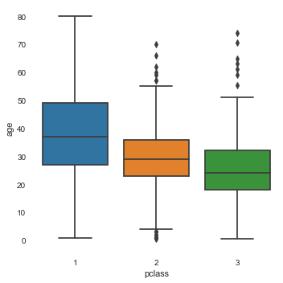

```python
sns.catplot(x='pclass', y='age', data=titanic, kind='box')
```

##### The diagram above shows that we have very young people in 3rd class and older people in 1st class. So age determined where a passenger would be.

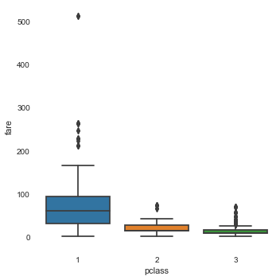

```python
sns.catplot(x='pclass', y='fare', data=titanic, kind='box')
```

##### The diagram shows that those in 1st class paid the most and those in 3rd class paid the least.

```python
titanic.pivot_table('survived', index='pclass')
```

| pclass | survived |
| --- | --- |
| 1 | 0.629630 |
| 2 | 0.472826 |
| 3 | 0.242363 |

##### The table shows that survival decreases from 1st class to 3rd class.

##### We can conclude from the diagrams that age determined the income of the passengers. The passenger incomes determined the class they boarded. The class they boarded determined whether they survived or not. So age is an essential feature.

##### We will consider the age feature and fill in the missing values.

```python
titanic[titanic['pclass']==1]['age'].median()
```

```
37.0
```

```python
def fill_age(cols):
    age = cols[0]
    pclass = cols[1]
    if pd.isnull(age):
        if pclass==1:
            return titanic[titanic['pclass']==1]['age'].median()
        elif pclass==2:
            return titanic[titanic['pclass']==2]['age'].median()
        elif pclass==3:
            return titanic[titanic['pclass']==3]['age'].median()
    else:
        return age
```

```python
# We fill in the missing values for age

titanic.age = titanic[['age', 'pclass']].apply(fill_age, axis=1)
```

```python
# We have no missing values for age

titanic.age.isnull().sum()
```

```
0
```

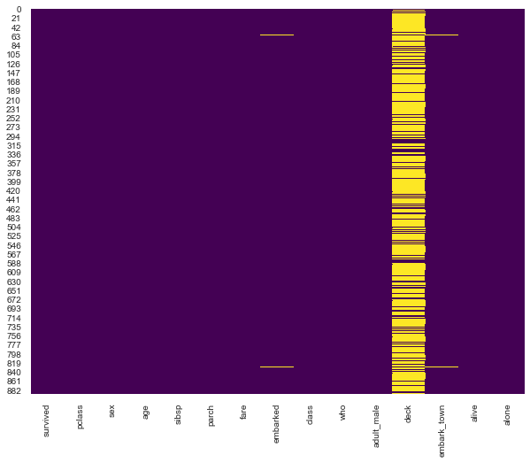

```python
# The diagram below shows we have no missing values for age

plt.figure(figsize=(10, 8))
sns.heatmap(titanic.isnull(), cbar=False, cmap='viridis')
```

##### We have some missing values for embarked. Let us analyse this feature.

#### **Analysis of the Feature Embarked**

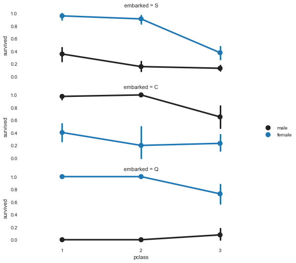

```python
f = sns.FacetGrid(titanic, row='embarked', height=2.5, aspect=3)
f.map(sns.pointplot, 'pclass', 'survived', 'sex', order=None, hue_order=None)
f.add_legend()
```

##### More women who embarked at ports S and Q survived than men who embarked at the same ports. More men who embarked at port C survived than women who embarked at the sampe port.

```python
titanic.embarked.value_counts()
```

```
S    644
C    168
Q     77
Name: embarked, dtype: int64
```

##### The highest number of passengers came from port S and the least came from port Q. We will fill the missing values with port S.

```python
titanic.embarked.fillna('S', inplace=True)
titanic.embarked.isnull().sum()
```

```
0
```

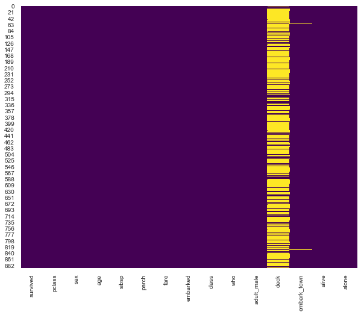

```python
plt.figure(figsize=(10, 8))
sns.heatmap(titanic.isnull(), cbar=False, cmap='viridis')
```

##### From the diagram above, we do not have missing values in embarked anymore.

#### **Analysing other Features**

##### * More than 50% of the values of feature deck are missing. So we will drop this feature.

##### * Embarked Town is a duplicate of embarked. So we will drop this feature.

##### * Alive is a duplicate of survived. So we will drop this feature.

##### * Adult male does not give an additional information.So we will drop this feature.

##### * Class is a duplicate of pclass. So we will drop this feature.

```python
titanic.drop(['class', 'adult_male', 'deck', 'embark_town', 'alive'], axis=1, inplace=True)
```

```python
titanic.head()
```

|  | survived | pclass | sex | age | sibsp | parch | fare | embarked | who | alone |
| --- | --- | --- | --- | --- | --- | --- | --- | --- | --- | --- |
| 0 | 0 | 3 | male | 22.0 | 1 | 0 | 7.2500 | S | man | False |
| 1 | 1 | 1 | female | 38.0 | 1 | 0 | 71.2833 | C | woman | False |
| 2 | 1 | 3 | female | 26.0 | 0 | 0 | 7.9250 | S | woman | True |
| 3 | 1 | 1 | female | 35.0 | 1 | 0 | 53.1000 | S | woman | False |
| 4 | 0 | 3 | male | 35.0 | 0 | 0 | 8.0500 | S | man | True |

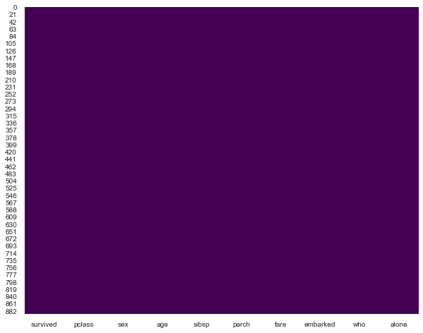

```python
plt.figure(figsize=(10, 8))
sns.heatmap(titanic.isnull(), cbar=False, cmap='viridis')
```

##### The diagram above shows we do not have any missing values in our data.

```python
titanic.dtypes
```

```
survived      int64
pclass        int64
sex          object
age         float64
sibsp         int64
parch         int64
fare        float64
embarked     object
who          object
alone          bool
dtype: object
```

```python
titanic['age'] = titanic['age'].astype('int')
titanic['fare'] = titanic['fare'].astype('int')
```

```python
titanic.head()
```

|  | survived | pclass | sex | age | sibsp | parch | fare | embarked | who | alone |
| --- | --- | --- | --- | --- | --- | --- | --- | --- | --- | --- |
| 0 | 0 | 3 | male | 22 | 1 | 0 | 7 | S | man | False |
| 1 | 1 | 1 | female | 38 | 1 | 0 | 71 | C | woman | False |
| 2 | 1 | 3 | female | 26 | 0 | 0 | 7 | S | woman | True |
| 3 | 1 | 1 | female | 35 | 1 | 0 | 53 | S | woman | False |
| 4 | 0 | 3 | male | 35 | 0 | 0 | 8 | S | man | True |

#### **Encoding our Data**

```python
titanic_enc = pd.get_dummies(titanic, columns=['pclass', 'sex', 'embarked', 'who', 'alone'])
titanic_enc.head()
```

|  | survived | age | sibsp | parch | fare | pclass_1 | pclass_2 | pclass_3 | sex_female | sex_male | embarked_C | embarked_Q | embarked_S | who_child | who_man | who_woman | alone_False | alone_True |
| --- | --- | --- | --- | --- | --- | --- | --- | --- | --- | --- | --- | --- | --- | --- | --- | --- | --- | --- |
| 0 | 0 | 22 | 1 | 0 | 7 | 0 | 0 | 1 | 0 | 1 | 0 | 0 | 1 | 0 | 1 | 0 | 1 | 0 |
| 1 | 1 | 38 | 1 | 0 | 71 | 1 | 0 | 0 | 1 | 0 | 1 | 0 | 0 | 0 | 0 | 1 | 1 | 0 |
| 2 | 1 | 26 | 0 | 0 | 7 | 0 | 0 | 1 | 1 | 0 | 0 | 0 | 1 | 0 | 0 | 1 | 0 | 1 |
| 3 | 1 | 35 | 1 | 0 | 53 | 1 | 0 | 0 | 1 | 0 | 0 | 0 | 1 | 0 | 0 | 1 | 1 | 0 |
| 4 | 0 | 35 | 0 | 0 | 8 | 0 | 0 | 1 | 0 | 1 | 0 | 0 | 1 | 0 | 1 | 0 | 0 | 1 |

#### **Splitting our Data and Training our Model**

```python
X = titanic_enc.drop(['survived'], axis=1)
y = titanic.survived
```

```python
X.shape, y.shape
```

```
((891, 17), (891,))
```

```python
X_train, X_test, y_train, y_test = train_test_split(X, y, test_size=0.33, random_state=0, stratify=y)
```

```python
X_train.shape, X_test.shape
```

```
((596, 17), (295, 17))
```

```python
# Random Forest Classifier

scores = cross_val_score(RandomForestClassifier(), X_train, y_train, cv=10, n_jobs=-1)
score_rfc = scores.mean()
score_rfc
```

```
0.7953107344632768
```

```python
# Gradient Boosting Classifier

scores = cross_val_score(GradientBoostingClassifier(), X_train, y_train, cv=10, n_jobs=-1)
score_gbc = scores.mean()
score_gbc
```

```
0.8154519774011298
```

```python
# Logistic Regression

scores = cross_val_score(LogisticRegression(), X_train, y_train, cv=10, n_jobs=-1)
score_logreg = scores.mean()
score_logreg
```

```
0.8087005649717515
```

```python
# Stochastic Gradient Classifier

scores = cross_val_score(SGDClassifier(), X_train, y_train, cv=10, n_jobs=-1)
score_sgd = scores.mean()
score_sgd
```

```
0.6707909604519774
```

```python
# Linear SVC

scores = cross_val_score(SVC(), X_train, y_train, cv=10, n_jobs=-1)
score_svc = scores.mean()
score_svc
```

```
0.6878248587570621
```

```python
# Decision Tree Classifier

scores = cross_val_score(DecisionTreeClassifier(), X_train, y_train, cv=10, n_jobs=-1)
score_tree = scores.mean()
score_tree
```

```
0.7886440677966101
```

```python
# Naive Bayes

scores = cross_val_score(GaussianNB(), X_train, y_train, cv=10, n_jobs=-1)
score_gnb = scores.mean()
score_gnb
```

```
0.7968361581920903
```

```python
# KNN

scores = cross_val_score(KNeighborsClassifier(), X_train, y_train, cv=10, n_jobs=-1)
score_knn = scores.mean()
score_knn
```

```
0.7298587570621468
```

```python
scores = pd.DataFrame(
    {'Models':['Random Forest Classifier', 'Gradient Boosting Classifier', 'Logistic Regression', 'SGDClassifier', 'Linear SVC', 'Decision Tree Classifier', 'Naive Bayes', 'KNN'],
     'score':[score_rfc, score_gbc, score_logreg, score_sgd, score_svc, score_tree, score_gnb, score_knn]})
scores.sort_values(by='score', ascending=False)
```

|  | Models | score |
| --- | --- | --- |
| 1 | Gradient Boosting Classifier | 0.815452 |
| 2 | Logistic Regression | 0.808701 |
| 6 | Naive Bayes | 0.796836 |
| 0 | Random Forest Classifier | 0.795311 |
| 5 | Decision Tree Classifier | 0.788644 |
| 7 | KNN | 0.729859 |
| 4 | Linear SVC | 0.687825 |
| 3 | SGDClassifier | 0.670791 |

```python
gbc = GradientBoostingClassifier().fit(X_train, y_train)
gen_score = gbc.score(X_test, y_test)
print('Generalization score:', gen_score)
```

```
Generalization score: 0.847457627118644
```